# Assessing the Impact of NPIs on Consumer Mobility Patterns and COVID-19 Transmission in the US

Joseph Zuccarelli, Laura Seaman, Kevin Rader

2023-08-30

In the following markdown document, we carry out all exploratory data analysis.

## Exploratory Data Analysis

First, let’s read in our two datasets.

```r
# Read in data
MA_data <- read.csv("/Users/jqz0816/Documents/MDPI/data/MA_data.csv")
MI_data <- read.csv("/Users/jqz0816/Documents/MDPI/data/MI_data.csv")
```

Next, let’s properly define the type of each feature.

```r
# Define features with proper types
MA_data$date <- as.Date(MA_data$date)
MA_data$day <- as.factor(MA_data$day)
MA_data$weekend <- as.factor(MA_data$weekend)
MA_data$emergency <- as.factor(MA_data$emergency)
MI_data$date <- as.Date(MI_data$date)
MI_data$day <- as.factor(MI_data$day)
MI_data$weekend <- as.factor(MI_data$weekend)
MI_data$emergency <- as.factor(MI_data$emergency)
```

Finally, let’s explore our data!

#### Non-Pharmaceutical Intervention Data

**Figure: Non-Pharmaceutical Intervention Stringency By Date**

**a.) Massachusetts**

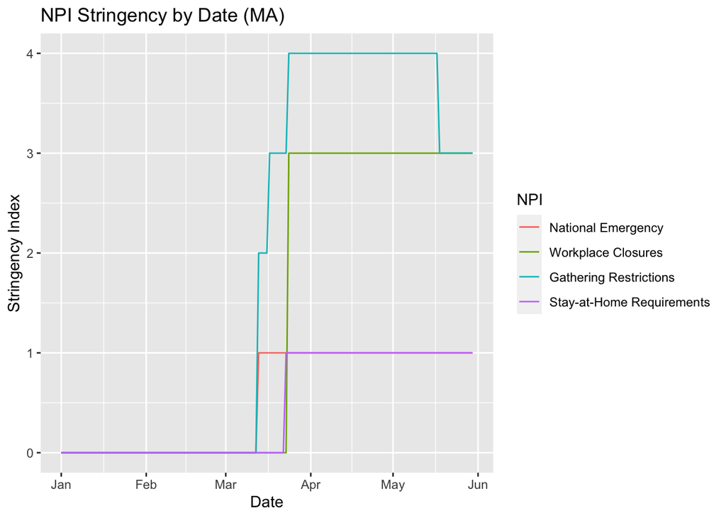

```r
# Plot: NPI by Date (MA Jan - May 2020)
MA_data_plot <- MA_data %>%
  filter(uuid=="0007561724B170454D13B2F6CE227C3D77F116951F5A75BC258349DD18AD0733") %>%
  select(date,emergency,work_closing,gather_restrict,stay_home_reqs)
MA_data_plot$emergency <- as.numeric(as.character(MA_data_plot$emergency))
MA_data_plot <- melt(MA_data_plot,id="date")
MA_data_plot %>%
  ggplot(aes(x=date,y=value,color=variable)) +
  geom_line() +
  scale_colour_discrete(labels=c("National Emergency", "Workplace Closures",
                                 "Gathering Restrictions",
                                 "Stay-at-Home Requirements")) +
  labs(x="Date",y="Stringency Index",title="NPI Stringency by Date (MA)",color="NPI")
```

**b.) Michigan**

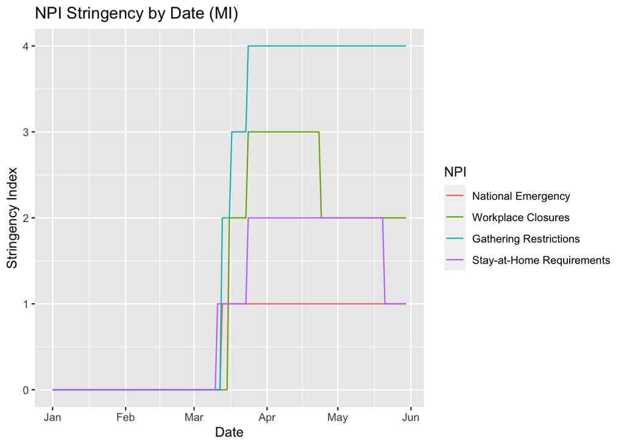

```r
# Plot: NPI by Date (MI Jan - May 2020)
MI_data_plot <- MI_data %>%
  filter(uuid=="000919F1AAA2A62098038034B268628BCAE1157EBC627042B45BFD7AF38A22C6") %>%
  select(date,emergency,work_closing,gather_restrict,stay_home_reqs)
MI_data_plot$emergency <- as.numeric(as.character(MI_data_plot$emergency))
MI_data_plot <- melt(MI_data_plot,id="date")
MI_data_plot %>%
  ggplot(aes(x=date,y=value,color=variable)) +
  geom_line() +
  scale_colour_discrete(labels=c("National Emergency", "Workplace Closures",
                                 "Gathering Restrictions",
                                 "Stay-at-Home Requirements")) +
  labs(x="Date",y="Stringency Index",title="NPI Stringency by Date (MI)",color="NPI")
```

**Table: Proportion of days by NPI Stringency Jan 1st - May 31st (MA & MI)**

```r
# NPI Table (MA)
MA_data_table <- MA_data %>%
  filter(uuid=="0007561724B170454D13B2F6CE227C3D77F116951F5A75BC258349DD18AD0733") %>%
  select(emergency,work_closing,gather_restrict,stay_home_reqs)

# NPI Table (MI)
MI_data_table <- MI_data %>%
  filter(uuid=="000919F1AAA2A62098038034B268628BCAE1157EBC627042B45BFD7AF38A22C6") %>%
  select(emergency,work_closing,gather_restrict,stay_home_reqs)

# Bind NPI Tables
MA_data_table$state <- as.factor("MA")
MI_data_table$state <- as.factor("MI")
data_table <- rbind(MA_data_table,MI_data_table)
```

```r
# Contingency Table (Workplace Closure)
test_work <- chisq.test(data_table$state,data_table$work_closing)
test_work$observed
```

```
##                 data_table$work_closing
## data_table$state  0  2  3
##               MA 83  0 68
##               MI 75 45 31
```

```r
# Chi-Square Test (Workplace Closure)
test_work
```

```
##
##  Pearson's Chi-squared test
##
## data:  data_table$state and data_table$work_closing
## X-squared = 59.233, df = 2, p-value = 1.373e-13
```

```r
# Contingency Table (Stay-at-Home Requirements)
test_home <- chisq.test(data_table$state,data_table$stay_home_reqs)
test_home$observed
```

```
##                 data_table$stay_home_reqs
## data_table$state  0  1  2
##               MA 82 69  0
##               MI 70 23 58
```

```r
# Chi-Square Test (Stay-at-Home Requirements)
test_home
```

```
##
##  Pearson's Chi-squared test
##
## data:  data_table$state and data_table$stay_home_reqs
## X-squared = 81.947, df = 2, p-value < 2.2e-16
```

```r
# Contingency Table (Gathering Restrictions)
test_gather <- chisq.test(data_table$state,data_table$gather_restrict)
test_gather$observed
```

```
##                 data_table$gather_restrict
## data_table$state  0  2  3  4
##               MA 72  4 20 55
##               MI 72  4  7 68
```

```r
# Chi-Square Test (Gathering Restrictions)
test_gather
```

```
##
##  Pearson's Chi-squared test
##
## data:  data_table$state and data_table$gather_restrict
## X-squared = 7.6332, df = 3, p-value = 0.05423
```

## Point-of-Sale Transaction Data

**Figure: State Maps**

**a.) Massachusetts**

```r
# Define area of interest (MA)
ma_state <- states(cb = TRUE, class = "sf") %>%
  filter(NAME == "Massachusetts")
ma_county <- counties(state = "MA", cb = TRUE, class = "sf")
ma_study_counties <- ma_county %>%
  filter(NAME =='Suffolk') %>%
  mutate(fill_color = 'coral')
```

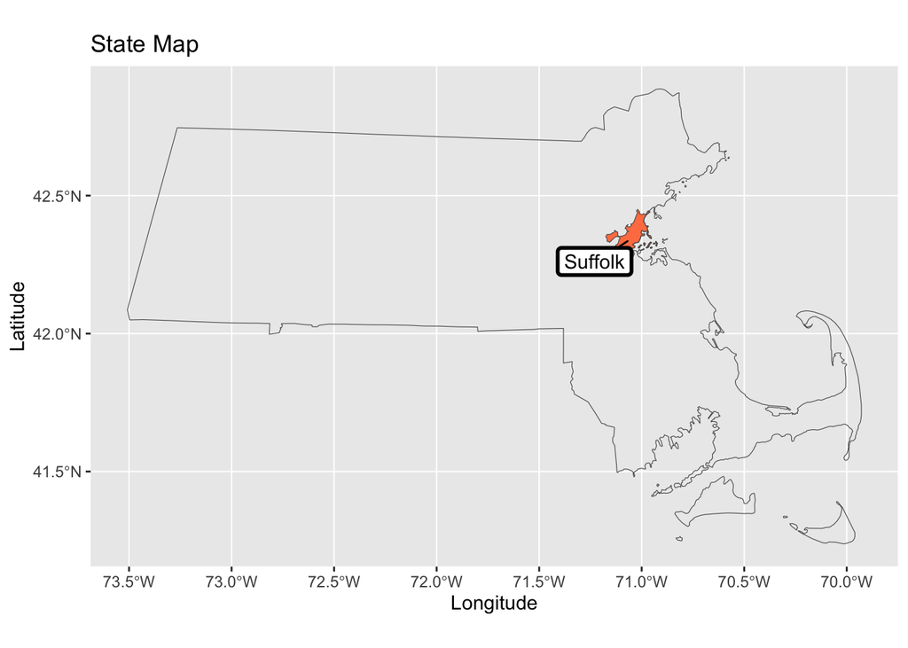

```r
# Plot: State Map (MA)
ma_study_counties %>%
  ggplot() +
  geom_sf(aes(fill = fill_color)) +
  geom_sf(data = ma_state, fill = NA) +
  geom_label_repel(data=ma_study_counties %>% filter(NAME=='Suffolk'),
    aes(label = "Suffolk", geometry = geometry),
    stat = "sf_coordinates",
    min.segment.length = 0,
    label.size = 1
    ) +
  scale_fill_identity() +
  labs(x="Longitude",y='Latitude',title='State Map')
```

**b.) Michigan**

```r
# Define area of interest (MI)
mi_state <- states(cb = TRUE, class = "sf") %>%
  filter(NAME == "Michigan")
mi_county <- counties(state = "MI", cb = TRUE, class = "sf")
mi_study_counties <- mi_county %>%
  filter(NAME =="Washtenaw") %>%
  mutate(fill_color = 'coral')
```

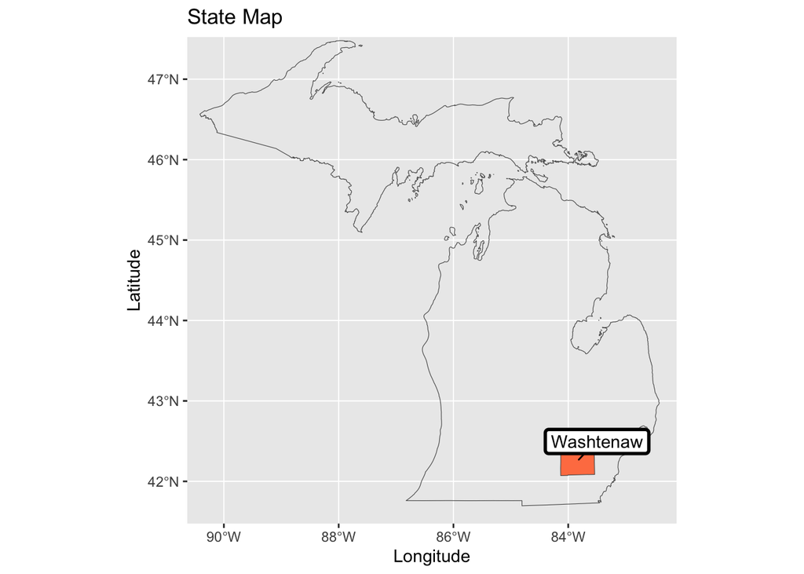

```r
# Plot: State Map (MI)
mi_study_counties %>%
  ggplot() +
  geom_sf(aes(fill = fill_color)) +
  geom_sf(data = mi_state, fill = NA) +
  coord_sf(xlim = c(-90.25,-82.5),ylim = c(41.75,47.25))+
  geom_label_repel(data=mi_study_counties %>% filter(NAME=='Washtenaw'),
    aes(label = 'Washtenaw', geometry = geometry),
    stat = "sf_coordinates",
    min.segment.length = 0,
    label.size = 1
    ) +
  scale_fill_identity() +
  labs(x="Longitude",y='Latitude',title='State Map')
```

```r
# Create MA df with idv features
MA_data_idv_pre <- MA_data %>%
  filter(emergency==0) %>%
  group_by(uuid) %>%
  summarise(avg_trans_day_pre = mean(num_transactions),
            avg_business_day_pre = mean(num_unique_businesses),
            avg_zips_day_pre = mean(num_unique_zips),
            avg_morning_day_pre = mean(num_morning),
            avg_afternoon_day_pre = mean(num_afternoon),
            avg_evening_day_pre = mean(num_evening),
            avg_night_day_pre = mean(num_night),
            avg_grocery_day_pre = mean(num_grocery),
            avg_convenience_day_pre = mean(num_convenience),
            avg_restaurant_day_pre = mean(num_restaurants))
MA_data_idv_post <- MA_data %>%
  filter(emergency==1) %>%
  group_by(uuid) %>%
  summarise(avg_trans_day_post = mean(num_transactions),
            avg_business_day_post = mean(num_unique_businesses),
            avg_zips_day_post = mean(num_unique_zips),
            avg_morning_day_post = mean(num_morning),
            avg_afternoon_day_post = mean(num_afternoon),
            avg_evening_day_post = mean(num_evening),
            avg_night_day_post = mean(num_night),
            avg_grocery_day_post = mean(num_grocery),
            avg_convenience_day_post = mean(num_convenience),
            avg_restaurant_day_post = mean(num_restaurants))
MA_data_idv <- merge(MA_data_idv_pre,MA_data_idv_post,by='uuid')
MA_data_idv <- MA_data_idv %>%
  mutate(trans_pct_chg = ((avg_trans_day_post-avg_trans_day_pre)/avg_trans_day_pre)*100,
         business_pct_chg = ((avg_business_day_post-avg_business_day_pre)/avg_business_day_pre)*100,
         zips_pct_chg = ((avg_zips_day_post-avg_zips_day_pre)/avg_zips_day_pre)*100) %>%
  arrange(trans_pct_chg)
feat_order <- c("uuid","avg_trans_day_pre","avg_trans_day_post","trans_pct_chg",
                "avg_business_day_pre","avg_business_day_post","business_pct_chg",
                "avg_zips_day_pre","avg_zips_day_post","zips_pct_chg",
                "avg_morning_day_pre","avg_morning_day_post",
                "avg_afternoon_day_pre","avg_afternoon_day_post",
                "avg_evening_day_pre","avg_evening_day_post",
                "avg_night_day_pre","avg_night_day_post",
                "avg_grocery_day_pre","avg_grocery_day_post",
                "avg_convenience_day_pre","avg_convenience_day_post",
                "avg_restaurant_day_pre","avg_restaurant_day_post")
MA_data_idv <- MA_data_idv[,feat_order]

# Create MI df with idv features
MI_data_idv_pre <- MI_data %>%
  filter(emergency==0) %>%
  group_by(uuid) %>%
  summarise(avg_trans_day_pre = mean(num_transactions),
            avg_business_day_pre = mean(num_unique_businesses),
            avg_zips_day_pre = mean(num_unique_zips),
            avg_morning_day_pre = mean(num_morning),
            avg_afternoon_day_pre = mean(num_afternoon),
            avg_evening_day_pre = mean(num_evening),
            avg_night_day_pre = mean(num_night),
            avg_grocery_day_pre = mean(num_grocery),
            avg_convenience_day_pre = mean(num_convenience),
            avg_restaurant_day_pre = mean(num_restaurants))
MI_data_idv_post <- MI_data %>%
  filter(emergency==1) %>%
  group_by(uuid) %>%
  summarise(avg_trans_day_post = mean(num_transactions),
            avg_business_day_post = mean(num_unique_businesses),
            avg_zips_day_post = mean(num_unique_zips),
            avg_morning_day_post = mean(num_morning),
            avg_afternoon_day_post = mean(num_afternoon),
            avg_evening_day_post = mean(num_evening),
            avg_night_day_post = mean(num_night),
            avg_grocery_day_post = mean(num_grocery),
            avg_convenience_day_post = mean(num_convenience),
            avg_restaurant_day_post = mean(num_restaurants))
MI_data_idv <- merge(MI_data_idv_pre,MI_data_idv_post,by='uuid')
MI_data_idv <- MI_data_idv %>%
  mutate(trans_pct_chg = ((avg_trans_day_post-avg_trans_day_pre)/avg_trans_day_pre)*100,
         business_pct_chg = ((avg_business_day_post-avg_business_day_pre)/avg_business_day_pre)*100,
         zips_pct_chg = ((avg_zips_day_post-avg_zips_day_pre)/avg_zips_day_pre)*100) %>%
  arrange(trans_pct_chg)
feat_order <- c("uuid","avg_trans_day_pre","avg_trans_day_post","trans_pct_chg",
                "avg_business_day_pre","avg_business_day_post","business_pct_chg",
                "avg_zips_day_pre","avg_zips_day_post","zips_pct_chg",
                "avg_morning_day_pre","avg_morning_day_post",
                "avg_afternoon_day_pre","avg_afternoon_day_post",
                "avg_evening_day_pre","avg_evening_day_post",
                "avg_night_day_pre","avg_night_day_post",
                "avg_grocery_day_pre","avg_grocery_day_post",
                "avg_convenience_day_pre","avg_convenience_day_post",
                "avg_restaurant_day_pre","avg_restaurant_day_post")
MI_data_idv <- MI_data_idv[,feat_order]
```

**Table: Daily Individual Consumer Behavior Before vs. During National Emergency**

**a.) Massachusetts**

```r
# View Top 6
head(MA_data_idv,6)
```

```
##                                                               uuid
## 1 6201A35FF0996271DC397BA2559CB1578BB084C08951645C20A07BD4A9B2BE55
## 2 83F76F625C0066DBE71A904F477249FBD098E3140DEBA077A85D8B5AB2CCF132
## 3 C3E7F9059261B6CD00EB7102066D4AAABE259D8216D09EEDD9E1BC4210BA398D
## 4 7910F0D2A1B75FB6E4B8B320D1F5B66863E237B202942F364158CD7F99318ADC
## 5 E6FE5AEC6C094D8B4667DD7CDEB282143A09B933157483ABF82DA161C0A2338D
## 6 1DDA40F1D1870C4A98E01671577C415D56B81F3FCA9524E9A88BBB322B55F425
##   avg_trans_day_pre avg_trans_day_post trans_pct_chg avg_business_day_pre
## 1          27.44444          1.0126582     -96.31015            16.097222
## 2          15.66667          0.9240506     -94.10180            11.055556
## 3          11.81944          0.7468354     -93.68130             1.583333
## 4          12.75000          0.9240506     -92.75254             1.000000
## 5          10.18056          0.7721519     -92.41542             1.486111
## 6          24.45833          1.9620253     -91.97809            18.625000
##   avg_business_day_post business_pct_chg avg_zips_day_pre avg_zips_day_post
```

[output cut: 41 more lines]

**b.) Michigan**

```r
# View Top 6
head(MI_data_idv,6)
```

```
##                                                               uuid
## 1 36CD5A00A5881C6A4706F22069E76454F05B007CD3C7F17B58C608CE917D3E23
## 2 D962A5D70B8B79E66F3FE034A07089A2A87F1224A3650CB22AD9115BC67067B3
## 3 57B141751998625E41EFC418CD6E6E1ABA837949D3BC1886AC408DCA475CEBAF
## 4 C4DC2443A9992D7BF0DEE9642C36746719B4B2489298153BB05BF89422263219
## 5 A75258B838DA1237AC036059E75099AB1D42AEDA7C95A00CA86F9112486B92FD
## 6 2482F8F49B8B6974E2B0F94485C004D810636722A374AF190D4FF1B7F8A370C4
##   avg_trans_day_pre avg_trans_day_post trans_pct_chg avg_business_day_pre
## 1         14.166667          0.8354430     -94.10276             5.972222
## 2         20.069444          1.4430380     -92.80978            15.277778
## 3          9.833333          0.7594937     -92.27634             6.152778
## 4         22.819444          2.1265823     -90.68083            14.750000
## 5         23.861111          2.3544304     -90.13277             2.583333
## 6         20.083333          2.0379747     -89.85241            17.333333
##   avg_business_day_post business_pct_chg avg_zips_day_pre avg_zips_day_post
```

[output cut: 41 more lines]

```r
# Create plotting idv df (MA)
MA_data_idv_pre$emergency <- "Before"
MA_data_idv_post$emergency <-  "During"
colnames(MA_data_idv_pre) <- c("uuid","avg_trans_day",
                "avg_business_day",
                "avg_zips_day",
                "avg_morning_day",
                "avg_afternoon_day",
                "avg_evening_day",
                "avg_night_day",
                "avg_grocery_day",
                "avg_convenience_day",
                "avg_restaurant_day","emergency")
colnames(MA_data_idv_post) <- c("uuid","avg_trans_day",
                "avg_business_day",
                "avg_zips_day",
                "avg_morning_day",
                "avg_afternoon_day",
                "avg_evening_day",
                "avg_night_day",
                "avg_grocery_day",
                "avg_convenience_day",
                "avg_restaurant_day","emergency")
MA_data_idv_plot <- rbind(MA_data_idv_pre,MA_data_idv_post)
MA_data_idv_plot$emergency <- factor(MA_data_idv_plot$emergency,levels=c('Before','During'))

# Create plotting idv df (MI)
MI_data_idv_pre$emergency <- "Before"
MI_data_idv_post$emergency <- "During"
colnames(MI_data_idv_pre) <- c("uuid","avg_trans_day",
                "avg_business_day",
                "avg_zips_day",
                "avg_morning_day",
                "avg_afternoon_day",
                "avg_evening_day",
                "avg_night_day",
                "avg_grocery_day",
                "avg_convenience_day",
                "avg_restaurant_day","emergency")
colnames(MI_data_idv_post) <- c("uuid","avg_trans_day",
                "avg_business_day",
                "avg_zips_day",
                "avg_morning_day",
                "avg_afternoon_day",
                "avg_evening_day",
                "avg_night_day",
                "avg_grocery_day",
                "avg_convenience_day",
                "avg_restaurant_day","emergency")
MI_data_idv_plot <- rbind(MI_data_idv_pre,MI_data_idv_post)
MI_data_idv_plot$emergency <- factor(MI_data_idv_plot$emergency,levels=c('Before','During'))
```

**Figure 13: Distribution of Individual Average Daily Transactions (Before vs. During National Emergency)**

**a.) Massachusetts**

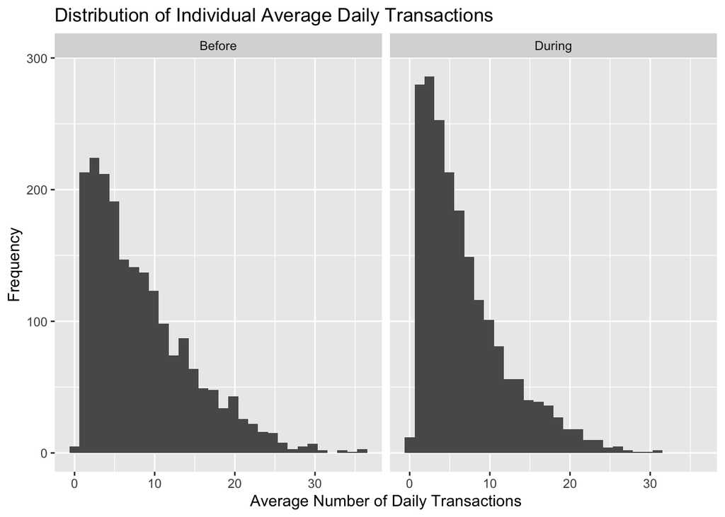

```r
# Plot: Distribution of Individual Average Daily Transactions (MA)
MA_data_idv_plot %>%
  ggplot(aes(x=avg_trans_day)) +
  geom_histogram() +
  facet_wrap(~emergency)+
  labs(x='Average Number of Daily Transactions',y='Frequency',title='Distribution of Individual Average Daily Transactions')
```

**b.) Michigan**

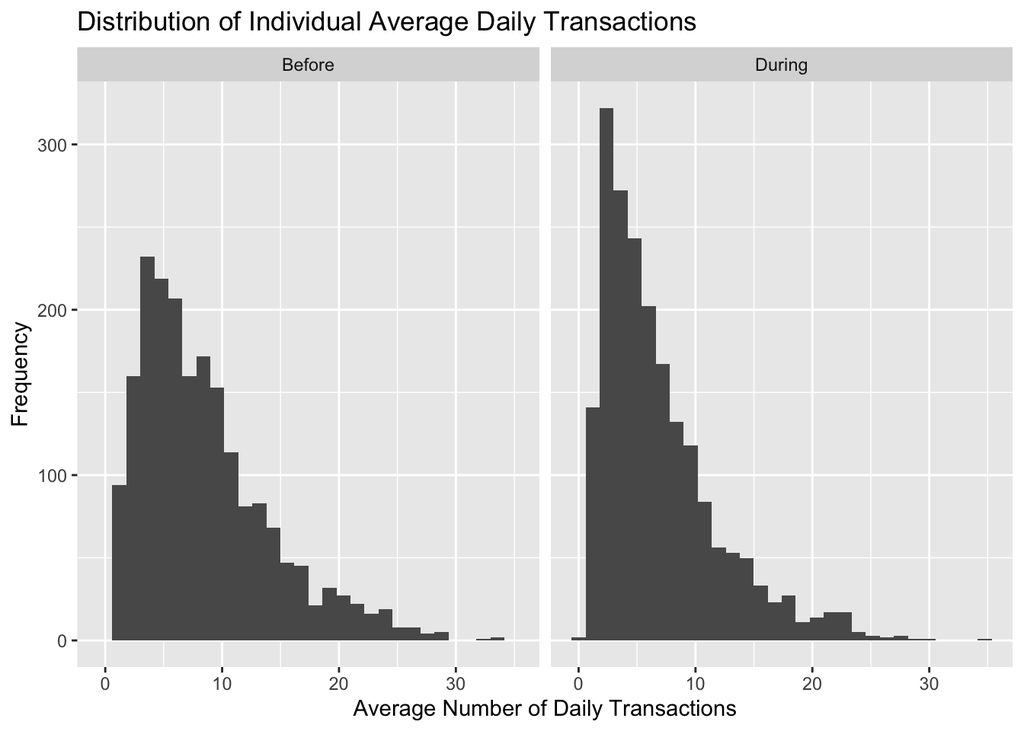

```r
# Plot: Distribution of Individual Average Daily Transactions (MI)
MI_data_idv_plot %>%
  ggplot(aes(x=avg_trans_day)) +
  geom_histogram() +
  facet_wrap(~emergency)+
  labs(x='Average Number of Daily Transactions',y='Frequency',title='Distribution of Individual Average Daily Transactions')
```

**Figure 14: Distribution of Individual Average Daily Businesses (Before vs. During National Emergency)**

**a.) Massachusetts**

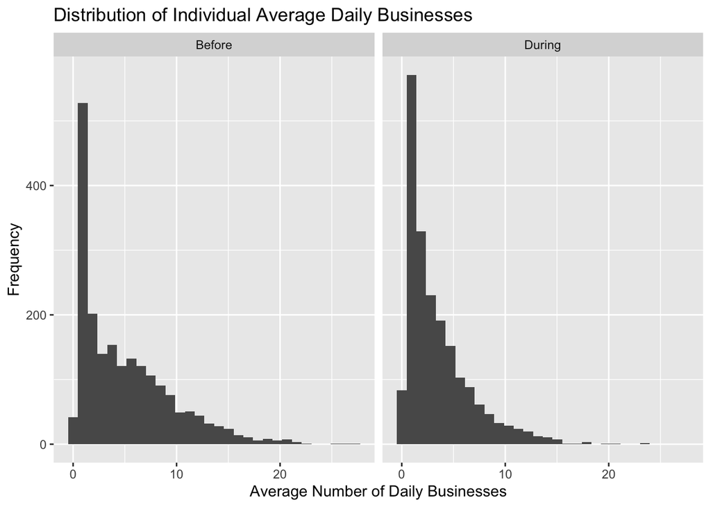

```r
# Plot: Distribution of Individual Average Daily Businesses (MA)
MA_data_idv_plot %>%
  ggplot(aes(x=avg_business_day)) +
  geom_histogram() +
  facet_wrap(~emergency)+
  labs(x='Average Number of Daily Businesses',y='Frequency',title='Distribution of Individual Average Daily Businesses')
```

**b.) Michigan**

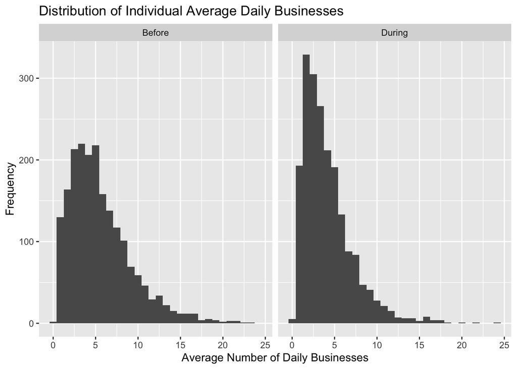

```r
# Plot: Distribution of Individual Average Daily Businesses (MI)
MI_data_idv_plot %>%
  ggplot(aes(x=avg_business_day)) +
  geom_histogram() +
  facet_wrap(~emergency)+
  labs(x='Average Number of Daily Businesses',y='Frequency',title='Distribution of Individual Average Daily Businesses')
```

**Figure 15: Distribution of Individual Average Daily Zip Codes (Before vs. During National Emergency)**

**a.) Massachusetts**

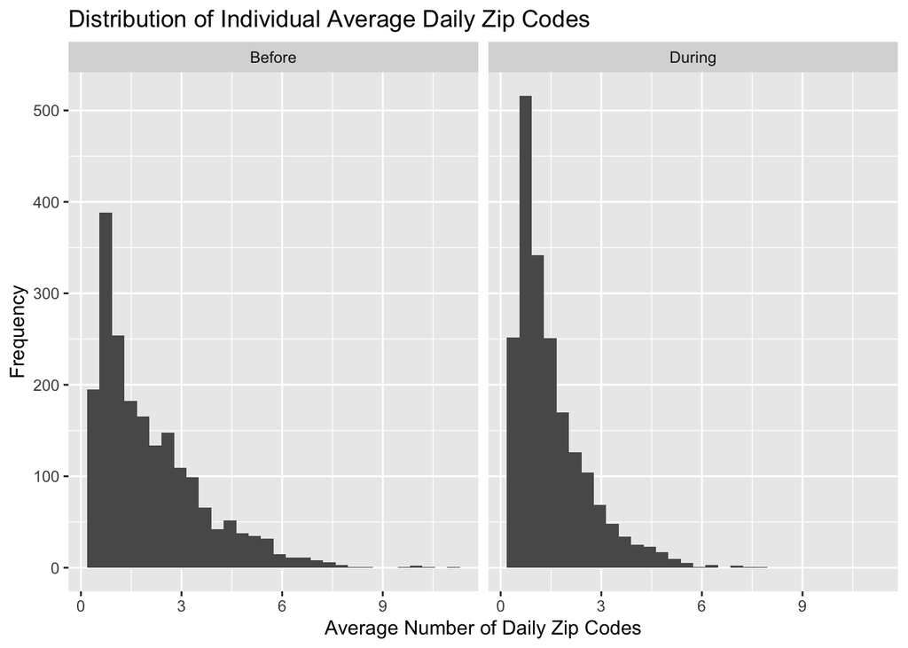

```r
# Plot: Distribution of Individual Average Daily Zip Codes (MA)
MA_data_idv_plot %>%
  ggplot(aes(x=avg_zips_day)) +
  geom_histogram() +
  facet_wrap(~emergency)+
  labs(x='Average Number of Daily Zip Codes',y='Frequency',title='Distribution of Individual Average Daily Zip Codes')
```

**b.) Michigan**

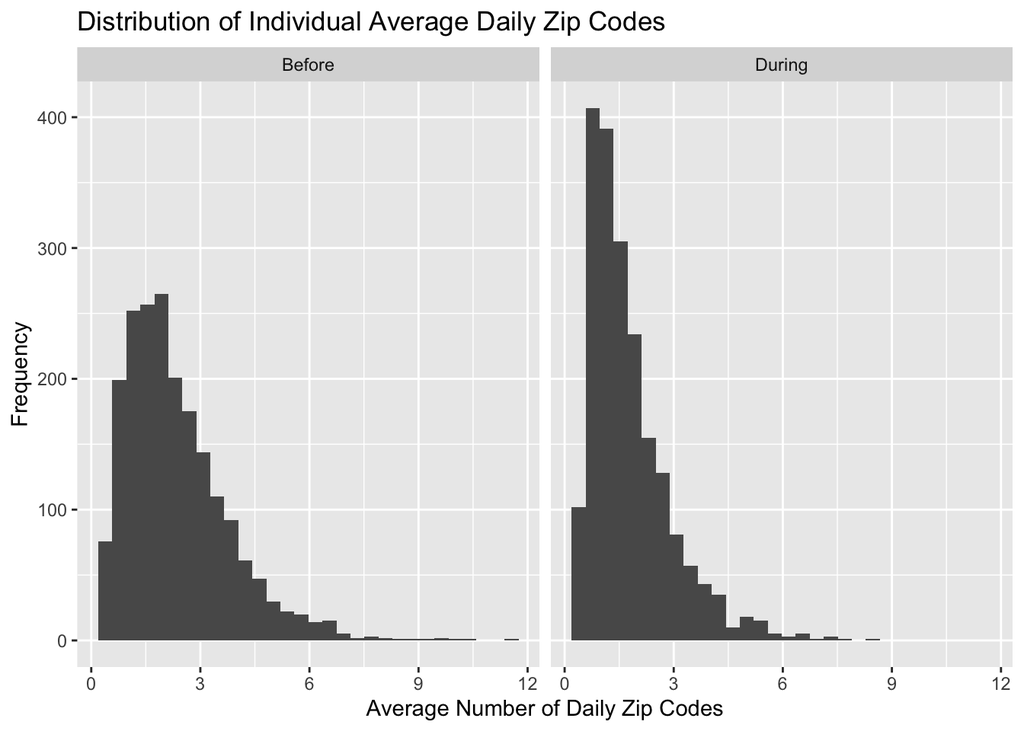

```r
# Plot: Distribution of Individual Average Daily Zip Codes (MI)
MI_data_idv_plot %>%
  ggplot(aes(x=avg_zips_day)) +
  geom_histogram() +
  facet_wrap(~emergency)+
  labs(x='Average Number of Daily Zip Codes',y='Frequency',title='Distribution of Individual Average Daily Zip Codes')
```

```r
# Create df with sample level features (MA)
MA_data_sample <- MA_data %>%
  group_by(date) %>%
  summarise(avg_trans = mean(num_transactions),
            avg_businesses = mean(num_unique_businesses),
            avg_zips = mean(num_unique_zips),
            avg_morning = mean(num_morning),
            avg_afternoon = mean(num_afternoon),
            avg_evening = mean(num_evening),
            avg_night = mean(num_night),
            avg_grocery = mean(num_grocery),
            avg_convenience = mean(num_convenience),
            avg_health = mean(num_health),
            avg_hotel = mean(num_hotels),
            avg_restaurant = mean(num_restaurants))


# Mutate rolling averages (time series)
MA_data_sample <- MA_data_sample %>%
            mutate(avg_trans_7day = rollmean(avg_trans, k=7, fill=NA, align='right'),
                   avg_businesses_7day = rollmean(avg_businesses, k=7, fill=NA, align='right'),
                   avg_zips_7day = rollmean(avg_zips, k=7, fill=NA, align='right'),
                   avg_morning_7day = rollmean(avg_morning, k=7, fill=NA, align='right'),
                   avg_afternoon_7day = rollmean(avg_afternoon, k=7, fill=NA, align='right'),
                   avg_evening_7day = rollmean(avg_evening, k=7, fill=NA, align='right'),
                   avg_night_7day = rollmean(avg_night, k=7, fill=NA, align='right'),
                   avg_grocery_7day = rollmean(avg_grocery, k=7, fill=NA, align='right'),
                   avg_convenience_7day = rollmean(avg_convenience, k=7, fill=NA, align='right'),
                   avg_health_7day = rollmean(avg_health, k=7, fill=NA, align='right'),
                   avg_hotel_7day = rollmean(avg_hotel, k=7, fill=NA, align='right'),
                   avg_restaurant_7day = rollmean(avg_restaurant, k=7, fill=NA, align='right'))

# Mutate day features
MA_data_sample$day <- wday(MA_data_sample$date,label = TRUE)
MA_data_sample$weekend <- ifelse(MA_data_sample$day %in% c("Sat", "Sun"), 1, 0)
MA_data_sample$emergency <- ifelse(MA_data_sample$date >= '2020-03-13', "During", "Before")
MA_data_sample$emergency <- as.factor(MA_data_sample$emergency)
MA_data_sample$emergency <- factor(MA_data_sample$emergency,levels = c('Before','During'))

# Create df with sample level features (MI)
MI_data_sample <- MI_data %>%
  group_by(date) %>%
  summarise(avg_trans = mean(num_transactions),
            avg_businesses = mean(num_unique_businesses),
            avg_zips = mean(num_unique_zips),
            avg_morning = mean(num_morning),
            avg_afternoon = mean(num_afternoon),
            avg_evening = mean(num_evening),
            avg_night = mean(num_night),
            avg_grocery = mean(num_grocery),
            avg_convenience = mean(num_convenience),
            avg_health = mean(num_health),
            avg_hotel = mean(num_hotels),
            avg_restaurant = mean(num_restaurants))


# Mutate rolling averages (time series)
MI_data_sample <- MI_data_sample %>%
            mutate(avg_trans_7day = rollmean(avg_trans, k=7, fill=NA, align='right'),
                   avg_businesses_7day = rollmean(avg_businesses, k=7, fill=NA, align='right'),
                   avg_zips_7day = rollmean(avg_zips, k=7, fill=NA, align='right'),
                   avg_morning_7day = rollmean(avg_morning, k=7, fill=NA, align='right'),
                   avg_afternoon_7day = rollmean(avg_afternoon, k=7, fill=NA, align='right'),
                   avg_evening_7day = rollmean(avg_evening, k=7, fill=NA, align='right'),
                   avg_night_7day = rollmean(avg_night, k=7, fill=NA, align='right'),
                   avg_grocery_7day = rollmean(avg_grocery, k=7, fill=NA, align='right'),
                   avg_convenience_7day = rollmean(avg_convenience, k=7, fill=NA, align='right'),
                   avg_health_7day = rollmean(avg_health, k=7, fill=NA, align='right'),
                   avg_hotel_7day = rollmean(avg_hotel, k=7, fill=NA, align='right'),
                   avg_restaurant_7day = rollmean(avg_restaurant, k=7, fill=NA, align='right'))

# Mutate day features
MI_data_sample$day <- wday(MI_data_sample$date,label = TRUE)
MI_data_sample$weekend <- ifelse(MI_data_sample$day %in% c("Sat", "Sun"), 1, 0)
MI_data_sample$emergency <- ifelse(MI_data_sample$date >= '2020-03-13', "During", "Before")
MI_data_sample$emergency <- as.factor(MI_data_sample$emergency)
MI_data_sample$emergency <- factor(MI_data_sample$emergency,levels = c('Before','During'))

# Bind DFs
MA_data_sample$state <- "Boston, MA"
MI_data_sample$state <- "Ann Arbor, MI"
data_sample <- rbind(MA_data_sample,MI_data_sample)
data_sample$state <- factor(data_sample$state, levels = c('Boston, MA',
                                                          'Ann Arbor, MI'))
```

**Figure: Average Individual Transactions by Date**

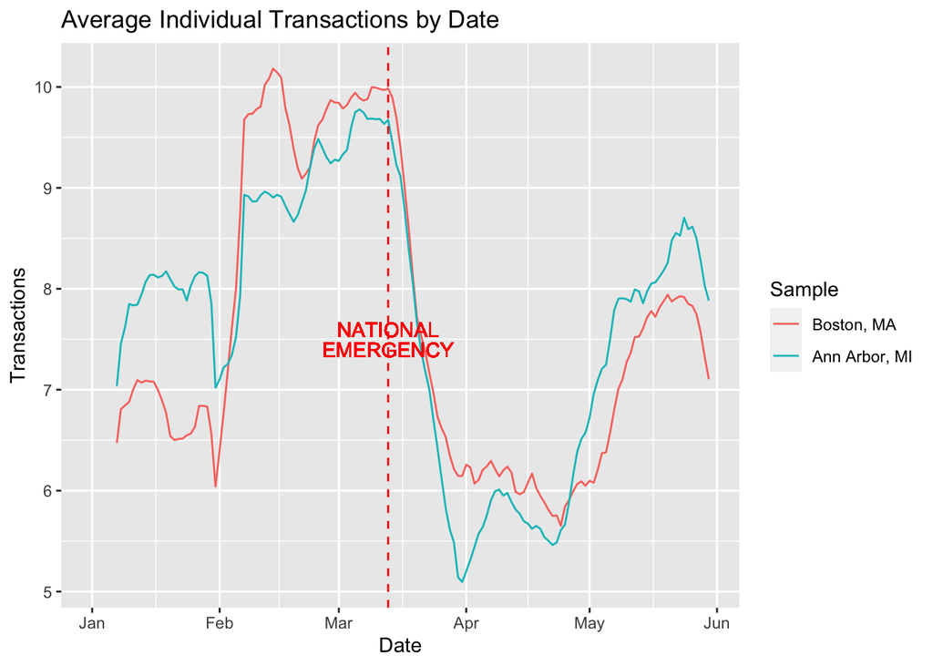

```r
# Plot: Individual Average Transactions by Date
emergency <- as.Date('2020-03-13')
data_sample %>%
  ggplot(aes(x=date,y=avg_trans_7day,color=state)) +
  geom_line() +
  geom_text(aes(x=ymd("2020-03-13"),y=(7.6),label='NATIONAL'),color='red')+
  geom_text(aes(x=ymd("2020-03-13"),y=(7.4),label='EMERGENCY'),color='red')+
  annotate(geom = "vline",
           x = c(emergency),
           xintercept = c(emergency),
           linetype = c("dashed"),
           color = c("red")) +
  labs(x='Date',y='Transactions', color="Sample",
       title='Average Individual Transactions by Date')
```

**Figure: Average Individual Businesses by Date**

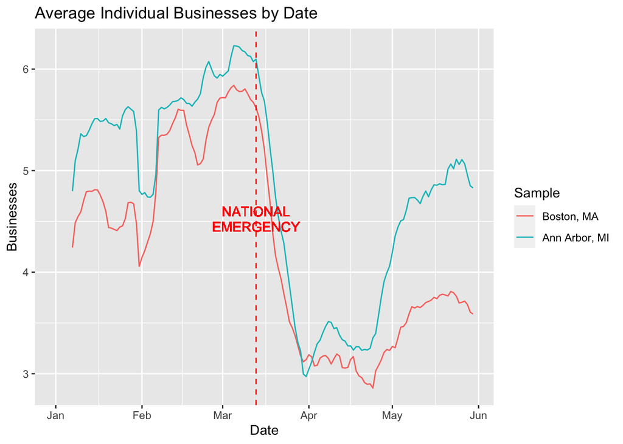

```r
# Plot: Sample Average Daily Businesses by Date
emergency <- as.Date('2020-03-13')
data_sample %>%
  ggplot(aes(x=date,y=avg_businesses_7day,color=state)) +
  geom_line() +
  geom_text(aes(x=ymd("2020-03-13"),y=(4.6),label='NATIONAL'),color='red')+
  geom_text(aes(x=ymd("2020-03-13"),y=(4.45),label='EMERGENCY'),color='red')+
  annotate(geom = "vline",
           x = c(emergency),
           xintercept = c(emergency),
           linetype = c("dashed"),
           color = c("red")) +
  labs(x='Date',y='Businesses', color="Sample",
       title='Average Individual Businesses by Date')
```

**Figure: Average Daily Zip Codes by Date**

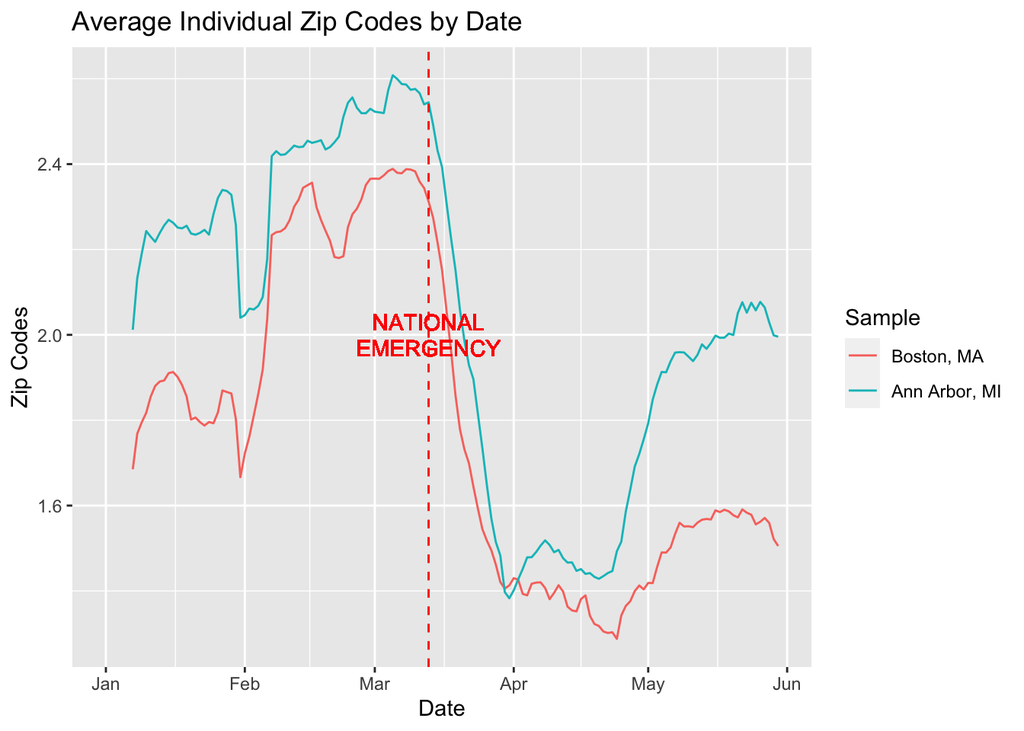

```r
# Plot: Sample Average Daily Zip Codes by Date
emergency <- as.Date('2020-03-13')
data_sample %>%
  ggplot(aes(x=date,y=avg_zips_7day,color=state)) +
  geom_line() +
  geom_text(aes(x=ymd("2020-03-13"),y=(2.03),label='NATIONAL'),color='red')+
  geom_text(aes(x=ymd("2020-03-13"),y=(1.97),label='EMERGENCY'),color='red')+
  annotate(geom = "vline",
           x = c(emergency),
           xintercept = c(emergency),
           linetype = c("dashed"),
           color = c("red")) +
  labs(x='Date',y='Zip Codes', color="Sample",
       title='Average Individual Zip Codes by Date')
```

**Figure: Average Individual Transactions by Business Type Over Time**

**a.) Massachusetts**

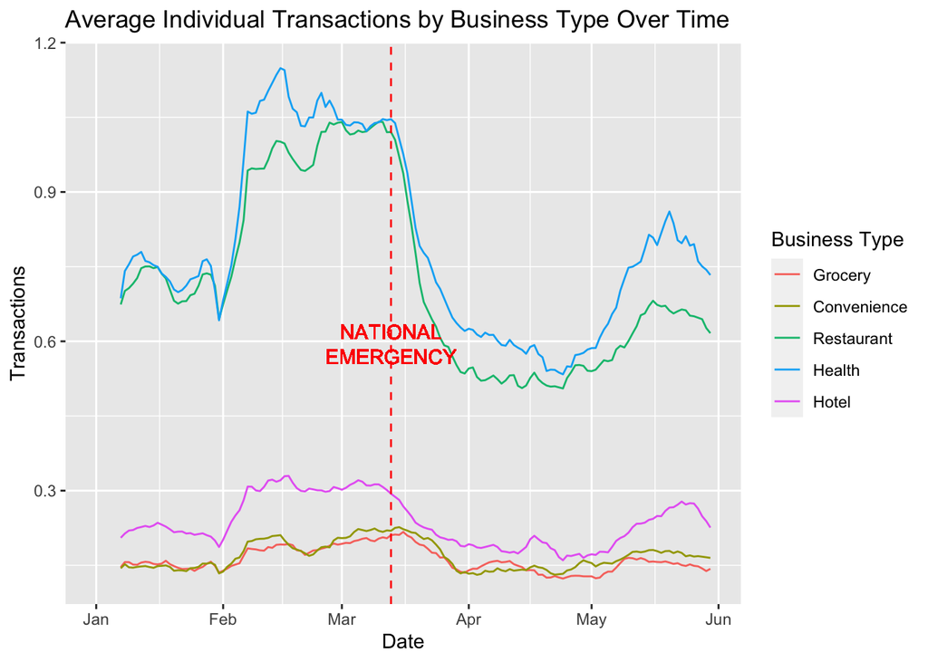

```r
# Plot: Average Individual Transactions by Business Type Over Time (MA)
MA_data_plot <- MA_data_sample %>%
  select(date,avg_grocery_7day,avg_convenience_7day,avg_restaurant_7day,avg_health_7day,avg_hotel_7day)
MA_data_plot <- melt(MA_data_plot,id="date")
MA_data_plot %>%
  ggplot(aes(x=date,y=value,color=variable)) +
  geom_line() +
  geom_text(aes(x=ymd('2020-03-13'),y=(0.62),label='NATIONAL'),color='red')+
  geom_text(aes(x=ymd('2020-03-13'),y=(0.57),label='EMERGENCY'),color='red')+
  annotate(geom = "vline",
           x = c(emergency),
           xintercept = c(emergency),
           linetype = c("dashed"),
           color = c("red")) +
  scale_colour_discrete(labels=c("Grocery", "Convenience", "Restaurant", "Health", "Hotel")) +
  labs(x="Date",y="Transactions",title="Average Individual Transactions by Business Type Over Time",color="Business Type")
```

**b.) Michigan**

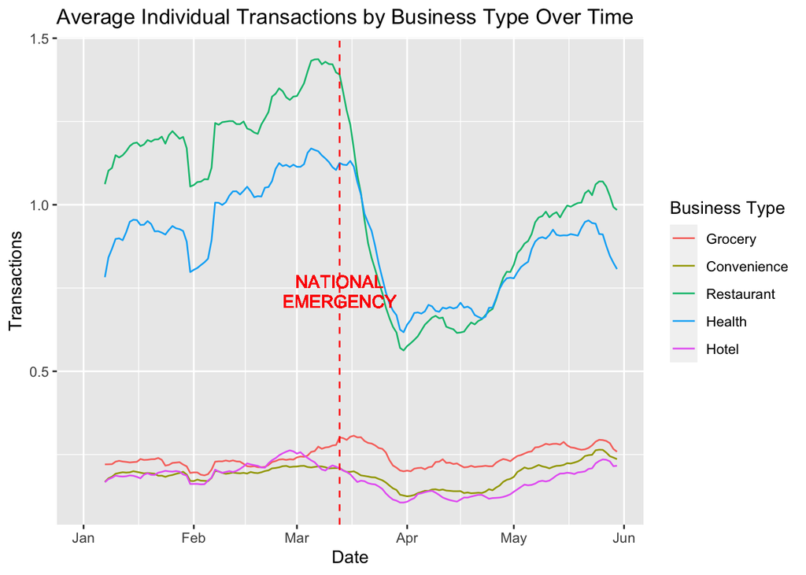

```r
# Plot: Average Individual Transactions by Business Type Over Time (MI)
MI_data_plot <- MI_data_sample %>%
  select(date,avg_grocery_7day,avg_convenience_7day,avg_restaurant_7day,avg_health_7day,avg_hotel_7day)
MI_data_plot <- melt(MI_data_plot,id="date")
MI_data_plot %>%
  ggplot(aes(x=date,y=value,color=variable)) +
  geom_line() +
  geom_text(aes(x=ymd('2020-03-13'),y=(0.77),label='NATIONAL'),color='red')+
  geom_text(aes(x=ymd('2020-03-13'),y=(0.71),label='EMERGENCY'),color='red')+
  annotate(geom = "vline",
           x = c(emergency),
           xintercept = c(emergency),
           linetype = c("dashed"),
           color = c("red")) +
  scale_colour_discrete(labels=c("Grocery", "Convenience", "Restaurant", "Health", "Hotel")) +
  labs(x="Date",y="Transactions",title="Average Individual Transactions by Business Type Over Time",color="Business Type")
```

**Figure: Average Individual Transactions by Time of Day Over Time**

**a.) Massachusetts**

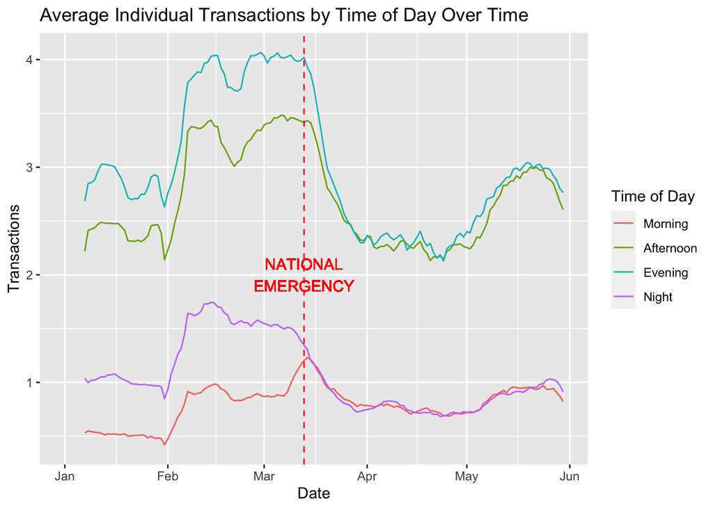

```r
# Plot: Average Daily Transactions by Time of Day Across Time (MA)
MA_data_plot <- MA_data_sample %>%
  select(date,avg_morning_7day,avg_afternoon_7day,avg_evening_7day,avg_night_7day)
MA_data_plot <- melt(MA_data_plot,id="date")
MA_data_plot %>%
  ggplot(aes(x=date,y=value,color=variable)) +
  geom_line() +
  geom_text(aes(x=ymd('2020-03-13'),y=(2.1),label='NATIONAL'),color='red')+
  geom_text(aes(x=ymd('2020-03-13'),y=(1.9),label='EMERGENCY'),color='red')+
  annotate(geom = "vline",
           x = c(emergency),
           xintercept = c(emergency),
           linetype = c("dashed"),
           color = c("red")) +
  scale_colour_discrete(labels=c("Morning","Afternoon","Evening","Night")) +
  labs(x="Date",y="Transactions",title="Average Individual Transactions by Time of Day Over Time",color="Time of Day")
```

**b.) Michigan**

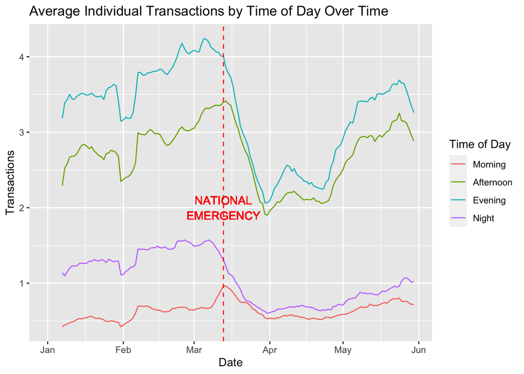

```r
# Plot: Average Daily Transactions by Time of Day Across Time (MI)
MI_data_plot <- MI_data_sample %>%
  select(date,avg_morning_7day,avg_afternoon_7day,avg_evening_7day,avg_night_7day)
MI_data_plot <- melt(MI_data_plot,id="date")
MI_data_plot %>%
  ggplot(aes(x=date,y=value,color=variable)) +
  geom_line() +
  geom_text(aes(x=ymd('2020-03-13'),y=(2.1),label='NATIONAL'),color='red')+
  geom_text(aes(x=ymd('2020-03-13'),y=(1.9),label='EMERGENCY'),color='red')+
  annotate(geom = "vline",
           x = c(emergency),
           xintercept = c(emergency),
           linetype = c("dashed"),
           color = c("red")) +
  scale_colour_discrete(labels=c("Morning","Afternoon","Evening","Night")) +
  labs(x="Date",y="Transactions",title="Average Individual Transactions by Time of Day Over Time",color="Time of Day")
```

**Figure: Distribution of Average Individual Daily Transactions by Day of the Week**

**a.) Massachusetts**

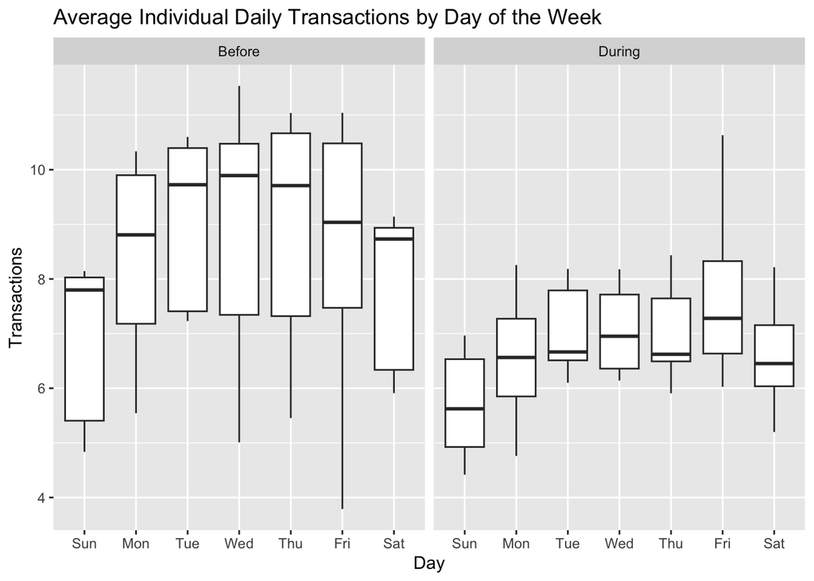

```r
# Plot: Average Individual Daily Transactions by Day of Week (MA)
MA_data_sample %>%
  ggplot(aes(x=day,y=avg_trans)) +
  geom_boxplot() +
  facet_wrap(~emergency) +
  labs(x="Day",y="Transactions",title="Average Individual Daily Transactions by Day of the Week")
```

**b.) Michigan**

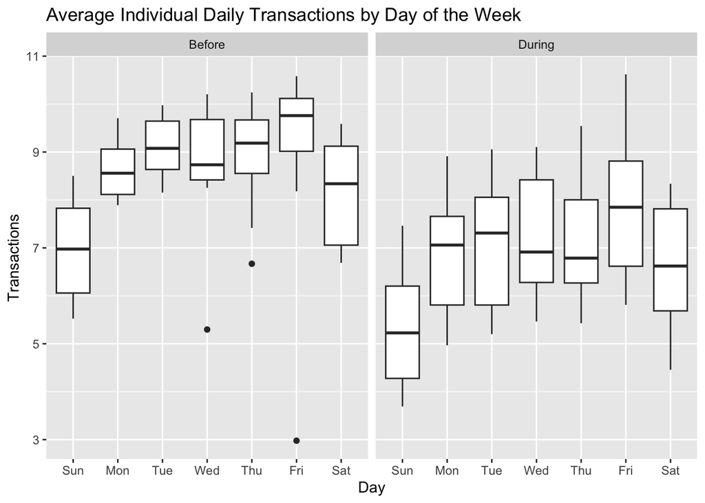

```r
# Plot: Average Individual Daily Transactions by Day of Week (MI)
MI_data_sample %>%
  ggplot(aes(x=day,y=avg_trans)) +
  geom_boxplot() +
  facet_wrap(~emergency) +
  labs(x="Day",y="Transactions",title="Average Individual Daily Transactions by Day of the Week")
```

## COVID-19 Case and Testing Data

**Figure: COVID-19 Case Rate by Date**

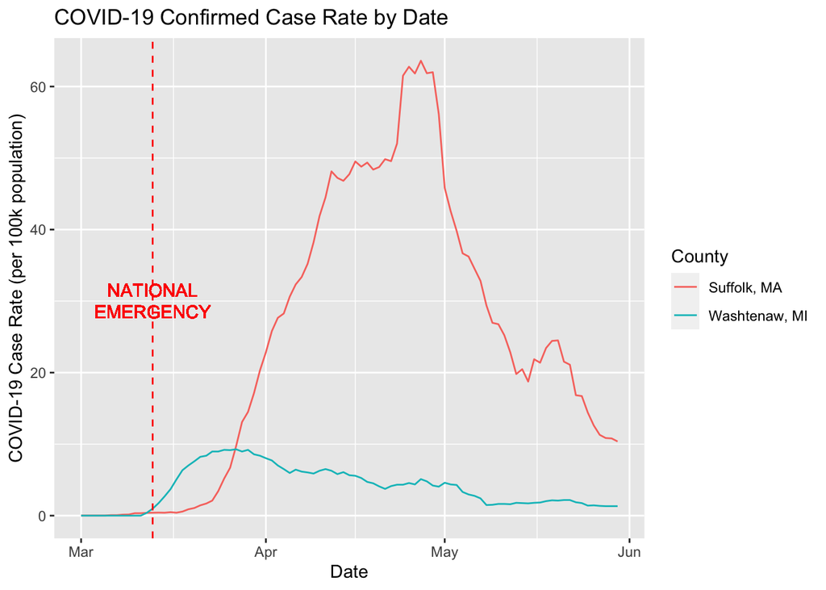

```r
# Plot: Daily COVID-19 Case Rate (per 100k population)
MA_data_plot <- MA_data %>%
  filter(uuid=="0007561724B170454D13B2F6CE227C3D77F116951F5A75BC258349DD18AD0733") %>%
  mutate(avg_case_7day = rollmean(case_rate, k=7, fill=NA, align='right')) %>%
  filter(date >= "2020-03-01")
MI_data_plot <- MI_data %>%
  filter(uuid=="000919F1AAA2A62098038034B268628BCAE1157EBC627042B45BFD7AF38A22C6") %>%
  mutate(avg_case_7day = rollmean(case_rate, k=7, fill=NA, align='right')) %>%
  filter(date >= "2020-03-01")
MA_data_plot$state <- "Suffolk, MA"
MI_data_plot$state <- "Washtenaw, MI"
data_plot <- rbind(MA_data_plot,MI_data_plot)
data_plot %>%
  ggplot(aes(x=date,y=avg_case_7day,color=state)) +
  geom_line() +
  geom_text(aes(x=ymd('2020-03-13'),y=(31.5),label='NATIONAL'),color='red')+
  geom_text(aes(x=ymd('2020-03-13'),y=(28.5),label='EMERGENCY'),color='red')+
  annotate(geom = "vline",
           x = c(emergency),
           xintercept = c(emergency),
           linetype = c("dashed"),
           color = c("red")) +
  labs(x='Date',y='COVID-19 Case Rate (per 100k population)', color="County",
       title='COVID-19 Confirmed Case Rate by Date')
```

**Figure: COVID-19 Test Rate by Date**

**a.) Massachusetts**

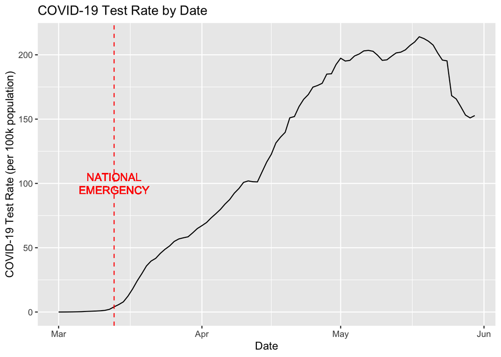

```r
# Plot: Daily COVID-19 Testing Rate (per 100k population) MA
MA_data_plot <- MA_data %>%
  filter(uuid=="0007561724B170454D13B2F6CE227C3D77F116951F5A75BC258349DD18AD0733") %>%
  mutate(avg_test_7day = rollmean(test_rate, k=7, fill=NA, align='right')) %>%
  filter(date >= "2020-03-01")
MA_data_plot %>%
  ggplot(aes(x=date,y=avg_test_7day)) +
  geom_line() +
  geom_text(aes(x=ymd('2020-03-13'),y=(105),label='NATIONAL'),color='red')+
  geom_text(aes(x=ymd('2020-03-13'),y=(95),label='EMERGENCY'),color='red')+
  annotate(geom = "vline",
           x = c(emergency),
           xintercept = c(emergency),
           linetype = c("dashed"),
           color = c("red")) +
  labs(x="Date",y="COVID-19 Test Rate (per 100k population)",title="COVID-19 Test Rate by Date")
```

**b.) Michigan**

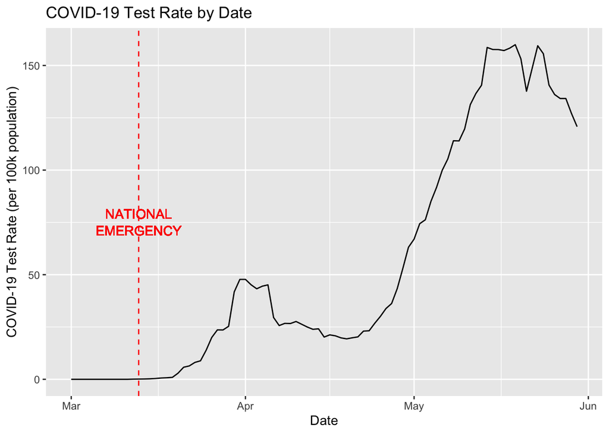

```r
# Plot: Daily COVID-19 Testing Rate (per 100k population) Washtenaw MI
MI_data_plot <- MI_data %>%
  filter(uuid=="000919F1AAA2A62098038034B268628BCAE1157EBC627042B45BFD7AF38A22C6") %>%
  mutate(avg_test_7day = rollmean(test_rate, k=7, fill=NA, align='right')) %>%
  filter(date >= "2020-03-01")
MI_data_plot %>%
  ggplot(aes(x=date,y=avg_test_7day)) +
  geom_line() +
  geom_text(aes(x=ymd('2020-03-13'),y=(79),label='NATIONAL'),color='red')+
  geom_text(aes(x=ymd('2020-03-13'),y=(71),label='EMERGENCY'),color='red')+
  annotate(geom = "vline",
           x = c(emergency),
           xintercept = c(emergency),
           linetype = c("dashed"),
           color = c("red")) +
  labs(x="Date",y="COVID-19 Test Rate (per 100k population)",title="COVID-19 Test Rate by Date")
```

**Figure: Daily COVID-19 Case Rate by Day of the Week**

**a.) Massachusetts**

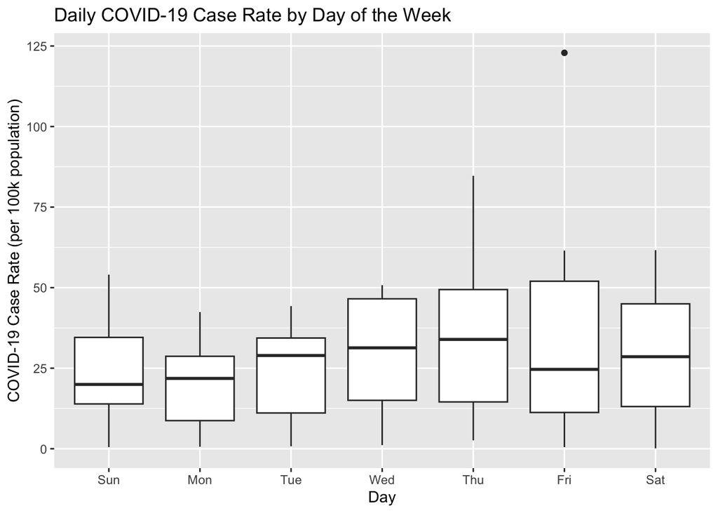

```r
# Plot: COVID-19 Case Rate (per 100k population) by Day of the Week (MA)
MA_data$day <- factor(MA_data$day,levels=c('Sun','Mon','Tue','Wed','Thu','Fri','Sat'))
MA_data %>%
  filter(uuid=="0007561724B170454D13B2F6CE227C3D77F116951F5A75BC258349DD18AD0733") %>%
  filter(date >= "2020-03-13") %>%
  ggplot(aes(x=day,y=case_rate)) +
  geom_boxplot() +
  labs(x="Day",y="COVID-19 Case Rate (per 100k population)",title="Daily COVID-19 Case Rate by Day of the Week")
```

**b.) Michigan**

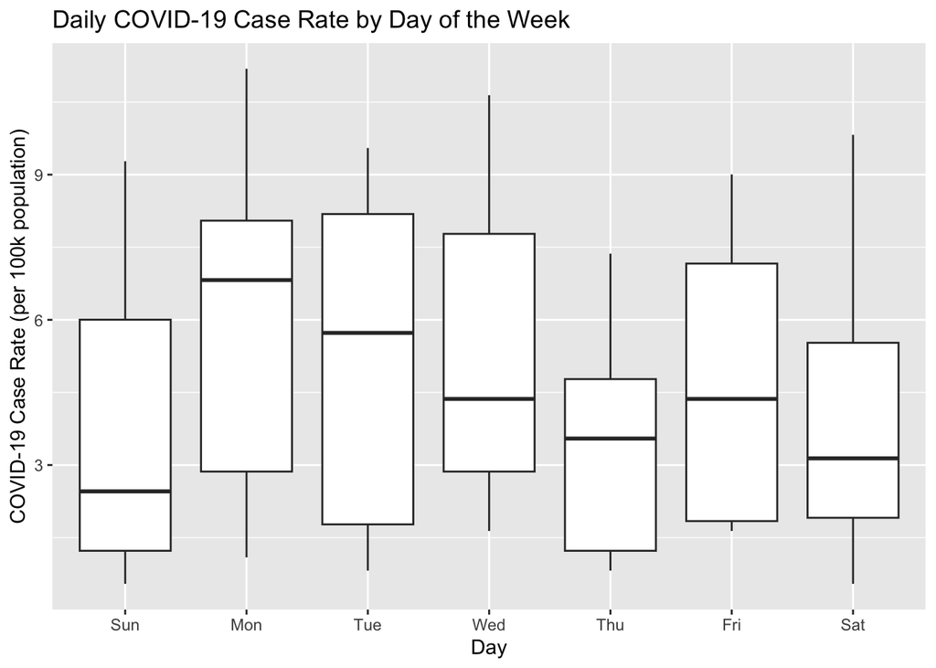

```r
# Plot: COVID-19 Case Rate (per 100k population) by Day of the Week (MI)
MI_data$day <- factor(MI_data$day,levels=c('Sun','Mon','Tue','Wed','Thu','Fri','Sat'))
MI_data %>%
  filter(uuid=="000919F1AAA2A62098038034B268628BCAE1157EBC627042B45BFD7AF38A22C6") %>%
  filter(date >= "2020-03-13") %>%
  ggplot(aes(x=day,y=case_rate)) +
  geom_boxplot() +
  labs(x="Day",y="COVID-19 Case Rate (per 100k population)",title="Daily COVID-19 Case Rate by Day of the Week")
```

**Figure: Daily COVID-19 Test Rate by Day of the Week**

**a.) Massachusetts**

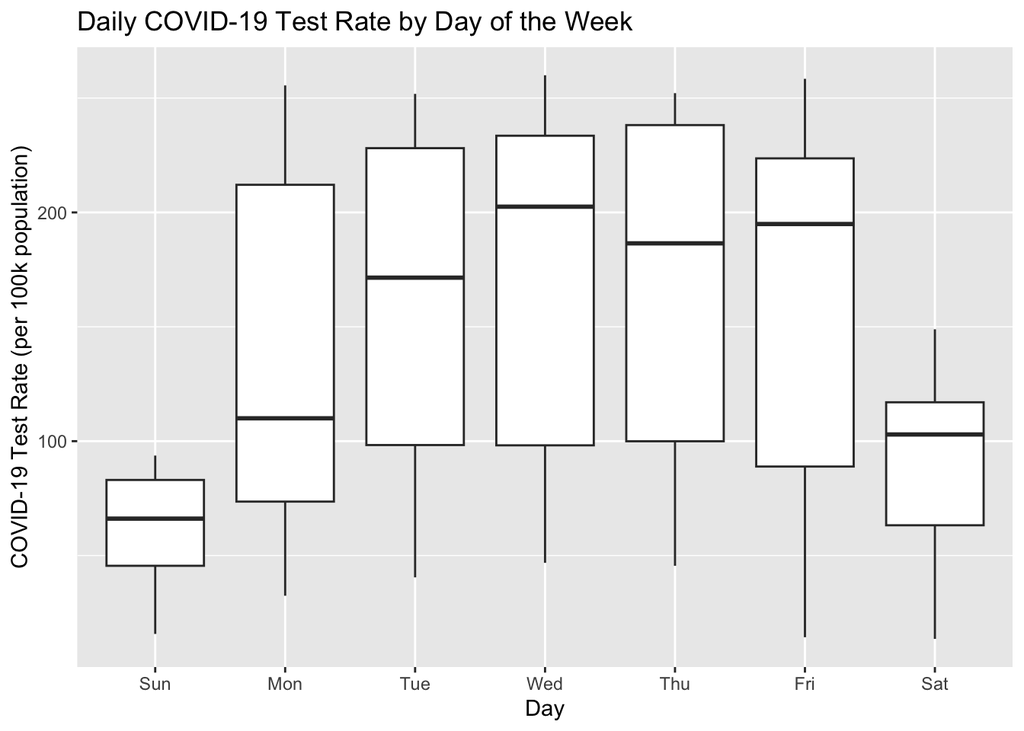

```r
# Plot: COVID-19 Testing Rate (per 100k population) by Day of the Week (MA)
MA_data %>%
  filter(uuid=="0007561724B170454D13B2F6CE227C3D77F116951F5A75BC258349DD18AD0733") %>%
  filter(date >= "2020-03-13") %>%
  ggplot(aes(x=day,y=test_rate)) +
  geom_boxplot() +
  labs(x="Day",y="COVID-19 Test Rate (per 100k population)",title="Daily COVID-19 Test Rate by Day of the Week")
```

**b.) Michigan**

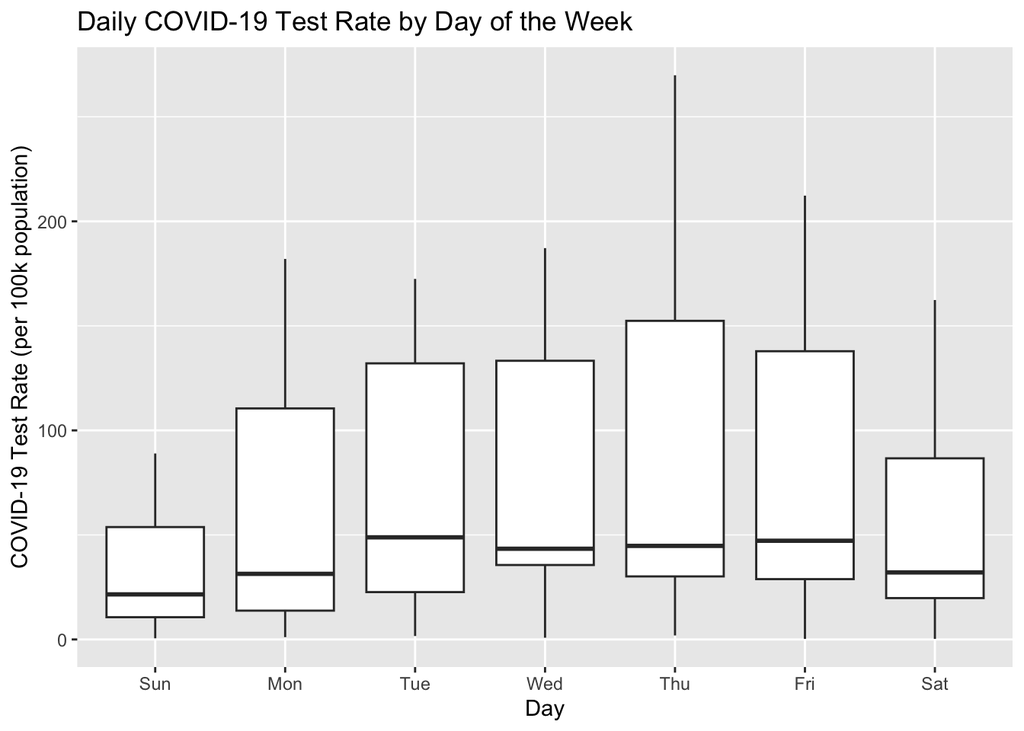

```r
# Plot: COVID-19 Testing Rate (per 100k population) by Day of the Week (MI)
MI_data %>%
  filter(uuid=="000919F1AAA2A62098038034B268628BCAE1157EBC627042B45BFD7AF38A22C6") %>%
  filter(date >= "2020-03-13") %>%
  ggplot(aes(x=day,y=test_rate)) +
  geom_boxplot() +
  labs(x="Day",y="COVID-19 Test Rate (per 100k population)",title="Daily COVID-19 Test Rate by Day of the Week")
```

**Table: NPIs, Transaction and COVID-19 Before/During National Emergency**

**a.) Massachusetts**

```r
# Summarize MA dataset (Before vs. During National Emergency)
MA_data$work_closing <- as.factor(MA_data$work_closing)
MA_data$gather_restrict <- as.factor(MA_data$gather_restrict)
MA_data$stay_home_reqs <- as.factor(MA_data$stay_home_reqs)
table1(~work_closing + gather_restrict + stay_home_reqs + num_transactions
       + num_unique_businesses + num_unique_zips
       + num_morning + num_afternoon + num_evening + num_night
       + num_grocery + num_convenience
       + num_hotels + num_health + num_restaurants
       + case_rate + test_rate
       | emergency,
       data=MA_data)
```

|  | 0 (N=144000) | 1 (N=158000) | Overall (N=302000) |
| --- | --- | --- | --- |
| work_closing |  |  |  |
| 0 | 144000 (100%) | 22000 (13.9%) | 166000 (55.0%) |
| 3 | 0 (0%) | 136000 (86.1%) | 136000 (45.0%) |
| gather_restrict |  |  |  |
| 0 | 144000 (100%) | 0 (0%) | 144000 (47.7%) |
| 2 | 0 (0%) | 8000 (5.1%) | 8000 (2.6%) |
| 3 | 0 (0%) | 40000 (25.3%) | 40000 (13.2%) |
| 4 | 0 (0%) | 110000 (69.6%) | 110000 (36.4%) |
| stay_home_reqs |  |  |  |
| 0 | 144000 (100%) | 20000 (12.7%) | 164000 (54.3%) |
| 1 | 0 (0%) | 138000 (87.3%) | 138000 (45.7%) |
| num_transactions |  |  |  |
| Mean (SD) | 8.40 (12.3) | 6.80 (10.9) | 7.57 (11.6) |
| Median [Min, Max] | 4.00 [0, 312] | 3.00 [0, 494] | 3.00 [0, 494] |
| num_unique_businesses |  |  |  |
| Mean (SD) | 5.05 (7.31) | 3.47 (5.53) | 4.22 (6.48) |
| Median [Min, Max] | 2.00 [0, 148] | 1.00 [0, 137] | 1.00 [0, 148] |
| num_unique_zips |  |  |  |
| Mean (SD) | 2.08 (2.65) | 1.50 (1.99) | 1.78 (2.35) |
| Median [Min, Max] | 1.00 [0, 38.0] | 1.00 [0, 40.0] | 1.00 [0, 40.0] |
| num_morning |  |  |  |
| Mean (SD) | 0.752 (2.95) | 0.828 (2.97) | 0.792 (2.96) |
| Median [Min, Max] | 0 [0, 245] | 0 [0, 292] | 0 [0, 292] |
| num_afternoon |  |  |  |
| Mean (SD) | 2.89 (5.49) | 2.53 (5.37) | 2.70 (5.43) |
| Median [Min, Max] | 0 [0, 147] | 0 [0, 218] | 0 [0, 218] |
| num_evening |  |  |  |
| Mean (SD) | 3.44 (6.02) | 2.61 (5.32) | 3.01 (5.68) |
| Median [Min, Max] | 0 [0, 231] | 0 [0, 240] | 0 [0, 240] |
| num_night |  |  |  |
| Mean (SD) | 1.32 (3.78) | 0.834 (2.88) | 1.06 (3.35) |
| Median [Min, Max] | 0 [0, 183] | 0 [0, 152] | 0 [0, 183] |
| num_grocery |  |  |  |
| Mean (SD) | 0.172 (0.884) | 0.151 (0.828) | 0.161 (0.855) |
| Median [Min, Max] | 0 [0, 62.0] | 0 [0, 48.0] | 0 [0, 62.0] |
| num_convenience |  |  |  |
| Mean (SD) | 0.177 (0.806) | 0.161 (0.967) | 0.169 (0.894) |
| Median [Min, Max] | 0 [0, 54.0] | 0 [0, 106] | 0 [0, 106] |
| num_hotels |  |  |  |
| Mean (SD) | 0.267 (1.30) | 0.209 (1.46) | 0.237 (1.39) |
| Median [Min, Max] | 0 [0, 84.0] | 0 [0, 119] | 0 [0, 119] |
| num_health |  |  |  |
| Mean (SD) | 0.912 (2.98) | 0.680 (2.79) | 0.791 (2.89) |
| Median [Min, Max] | 0 [0, 133] | 0 [0, 213] | 0 [0, 213] |
| num_restaurants |  |  |  |
| Mean (SD) | 0.864 (2.28) | 0.596 (2.06) | 0.724 (2.17) |
| Median [Min, Max] | 0 [0, 171] | 0 [0, 193] | 0 [0, 193] |
| case_rate |  |  |  |
| Mean (SD) | 0.0399 (0.172) | 28.2 (21.6) | 14.8 (21.0) |
| Median [Min, Max] | 0 [0, 1.25] | 26.4 [0.125, 123] | 0.749 [0, 123] |
| test_rate |  |  |  |
| Mean (SD) | 0.221 (0.837) | 137 (77.4) | 71.6 (88.2) |
| Median [Min, Max] | 0 [0, 6.27] | 112 [13.6, 260] | 30.5 [0, 260] |

**a.) Michigan**

```r
# Summarize MI dataset (Before vs. During National Emergency)
MI_data$work_closing <- as.factor(MI_data$work_closing)
MI_data$gather_restrict <- as.factor(MI_data$gather_restrict)
MI_data$stay_home_reqs <- as.factor(MI_data$stay_home_reqs)
table1(~work_closing + gather_restrict + stay_home_reqs + num_transactions
       + num_unique_businesses + num_unique_zips
       + num_morning + num_afternoon + num_evening + num_night
       + num_grocery + num_convenience
       + num_hotels + num_health + num_restaurants
       + case_rate + test_rate
       | emergency,
       data=MI_data)
```

|  | 0 (N=144000) | 1 (N=158000) | Overall (N=302000) |
| --- | --- | --- | --- |
| work_closing |  |  |  |
| 0 | 144000 (100%) | 6000 (3.8%) | 150000 (49.7%) |
| 2 | 0 (0%) | 90000 (57.0%) | 90000 (29.8%) |
| 3 | 0 (0%) | 62000 (39.2%) | 62000 (20.5%) |
| gather_restrict |  |  |  |
| 0 | 144000 (100%) | 0 (0%) | 144000 (47.7%) |
| 2 | 0 (0%) | 8000 (5.1%) | 8000 (2.6%) |
| 3 | 0 (0%) | 14000 (8.9%) | 14000 (4.6%) |
| 4 | 0 (0%) | 136000 (86.1%) | 136000 (45.0%) |
| stay_home_reqs |  |  |  |
| 0 | 140000 (97.2%) | 0 (0%) | 140000 (46.4%) |
| 1 | 4000 (2.8%) | 42000 (26.6%) | 46000 (15.2%) |
| 2 | 0 (0%) | 116000 (73.4%) | 116000 (38.4%) |
| num_transactions |  |  |  |
| Mean (SD) | 8.53 (11.4) | 6.90 (10.7) | 7.67 (11.1) |
| Median [Min, Max] | 5.00 [0, 513] | 3.00 [0, 484] | 4.00 [0, 513] |
| num_unique_businesses |  |  |  |
| Mean (SD) | 5.58 (7.08) | 4.14 (6.01) | 4.83 (6.58) |
| Median [Min, Max] | 3.00 [0, 392] | 2.00 [0, 315] | 3.00 [0, 392] |
| num_unique_zips |  |  |  |
| Mean (SD) | 2.35 (2.66) | 1.77 (2.27) | 2.05 (2.48) |
| Median [Min, Max] | 2.00 [0, 38.0] | 1.00 [0, 30.0] | 1.00 [0, 38.0] |
| num_morning |  |  |  |
| Mean (SD) | 0.609 (2.67) | 0.642 (2.68) | 0.627 (2.67) |
| Median [Min, Max] | 0 [0, 367] | 0 [0, 438] | 0 [0, 438] |
| num_afternoon |  |  |  |
| Mean (SD) | 2.86 (5.24) | 2.56 (5.23) | 2.71 (5.24) |
| Median [Min, Max] | 0 [0, 235] | 0 [0, 167] | 0 [0, 235] |
| num_evening |  |  |  |
| Mean (SD) | 3.70 (5.70) | 2.90 (5.39) | 3.28 (5.56) |
| Median [Min, Max] | 1.00 [0, 118] | 0 [0, 266] | 1.00 [0, 266] |
| num_night |  |  |  |
| Mean (SD) | 1.36 (3.53) | 0.795 (2.73) | 1.06 (3.15) |
| Median [Min, Max] | 0 [0, 179] | 0 [0, 179] | 0 [0, 179] |
| num_grocery |  |  |  |
| Mean (SD) | 0.231 (0.965) | 0.250 (1.10) | 0.241 (1.04) |
| Median [Min, Max] | 0 [0, 65.0] | 0 [0, 61.0] | 0 [0, 65.0] |
| num_convenience |  |  |  |
| Mean (SD) | 0.196 (0.741) | 0.183 (0.919) | 0.189 (0.839) |
| Median [Min, Max] | 0 [0, 44.0] | 0 [0, 76.0] | 0 [0, 76.0] |
| num_hotels |  |  |  |
| Mean (SD) | 0.203 (1.12) | 0.156 (1.06) | 0.179 (1.09) |
| Median [Min, Max] | 0 [0, 104] | 0 [0, 78.0] | 0 [0, 104] |
| num_health |  |  |  |
| Mean (SD) | 0.990 (2.75) | 0.803 (2.75) | 0.892 (2.75) |
| Median [Min, Max] | 0 [0, 141] | 0 [0, 180] | 0 [0, 180] |
| num_restaurants |  |  |  |
| Mean (SD) | 1.23 (2.65) | 0.826 (2.14) | 1.02 (2.41) |
| Median [Min, Max] | 0 [0, 89.0] | 0 [0, 108] | 0 [0, 108] |
| case_rate |  |  |  |
| Mean (SD) | 0.0379 (0.319) | 4.58 (3.01) | 2.42 (3.15) |
| Median [Min, Max] | 0 [0, 2.73] | 3.82 [0.546, 11.2] | 0.819 [0, 11.2] |
| test_rate |  |  |  |
| Mean (SD) | 0.00758 (0.0639) | 68.8 (62.9) | 36.0 (57.0) |
| Median [Min, Max] | 0 [0, 0.546] | 36.0 [0.273, 270] | 0.819 [0, 270] |